# Análisis movimiento

2025-05-05

# Procesamiento y limpieza de datos GPS

En esta sección se ve el procesamiento y limpieza de los datos. También se incorporan variables clave para el análisis del movimiento.

## 1. Carga de librerías

Se cargan los paquetes necesarios.

```r
library(tidyverse)  # Preparación y manipulación de datos
library(geosphere)  # Calcular distancias geográficas
library(leaflet)    # Visualizar los puntos en mapas interactivos
library(scales)     # Formatear escalas
library(sf)         # Manejar objetos espaciales (Simple Features)
library(rmarkdown)  # Generación del HTML para visualizar el código, graficos, tablas, etc.
library(gganimate)  # Animaciones
```

## 2. Carga y preprocesamiento de los datos

Se importa el archivo `.csv` con los puntos GPS y se renombran las columnas para mayor claridad. Además, se convierten las fechas a formato `POSIXct` y se ordenan los registros cronológicamente para cada perro.

```r
gps_data_raw <- read.csv("data/puntos-perros-movebank.csv") %>%
  select(dog_id = tag.local.identifier, timestamp, lon = location.long, lat = location.lat) %>%
  mutate(timestamp = ymd_hms(timestamp)) %>%
  arrange(dog_id, timestamp)
```

## 3. Cálculo de variables espaciales y temporales

Se agregan variables útiles para el análisis del movimiento.

```r
gps_data_raw <- gps_data_raw %>%
  group_by(dog_id) %>%
  mutate(
    lon_prev = lag(lon),
    lat_prev = lag(lat),
    time_prev = lag(timestamp),
    dist_m = distHaversine(cbind(lon, lat), cbind(lon_prev, lat_prev)),  # Distancia entre puntos consecutivos en metros
    time_diff_s = as.numeric(difftime(timestamp, time_prev, units = "secs")),  # Diferencia de tiempo en segundos
    speed_ms = dist_m / time_diff_s  # Velocidad en metros por segundo
  )
```

- **`lon_prev` y `lat_prev`**: Estas variables guardan la longitud (`lon_prev`) y latitud (`lat_prev`) del punto anterior para cada perro.
- **`time_prev`**: Almacena la marca de tiempo (`timestamp`) del punto anterior, permitiendo calcular la duración entre posiciones sucesivas.
- **`dist_m`**: Representa la distancia en metros entre el punto actual y el anterior, calculada usando la fórmula de Haversine (`distHaversine()` del paquete `geosphere`), que estima la distancia entre dos coordenadas geográficas sobre la superficie de la Tierra.
- **`time_diff_s`**: Es la diferencia de tiempo entre el punto actual y el anterior, medida en segundos.
- **`speed_ms`**: Esta es la velocidad entre dos puntos consecutivos, expresada en metros por segundo. Se obtiene dividiendo la distancia recorrida (`dist_m`) entre el tiempo transcurrido (`time_diff_s`).

## 4. Limpieza de registros con velocidad anómala

Se filtran los registros con velocidades irreales para un perro doméstico (> 10 m/s) o no definidas (`NA` o infinitos). Esto ayuda a eliminar errores de GPS u otras inconsistencias en el registro.

```r
gps_data_clean <- gps_data_raw %>%
  group_by(dog_id) %>%
  filter(is.na(speed_ms) | speed_ms > 0, speed_ms < 10) %>%
  filter(is.finite(speed_ms))

rm(gps_data_raw)  # Libera memoria eliminando el dataset original
```

## 5. Cálculo del ángulo de movimiento y su cambio

Se calcula el ángulo de movimiento entre puntos consecutivos, así como el cambio de dirección (variación de ángulo) entre cada paso.

```r
gps_data_clean <- gps_data_clean %>%
  group_by(dog_id) %>%
  mutate(
    angle = atan2(lat - lat_prev, lon - lon_prev),  # Ángulo de desplazamiento
    angle_change = abs(angle - lag(angle))  # Cambio absoluto de ángulo
  )
```

También se reemplazan todos los valores `NA` o infinitos por `NA`, y luego se eliminan todas las filas que tengan al menos un valor numérico faltante.

```r
gps_data_clean <- gps_data_clean %>%
  mutate(across(where(is.numeric), ~replace(., !is.finite(.) | is.na(.), NA))) %>%
  filter(if_all(where(is.numeric), ~!is.na(.)))
```

Volviendo al cálculo de los ángulos; para cada punto de localización GPS, se calcula el **ángulo de desplazamiento (`angle`)** utilizando la función `atan2()`. Este ángulo mide la dirección del movimiento del perro entre dos puntos consecutivos en el plano de coordenadas, en radianes, donde:

- Un valor cercano a 0 de `angle` indica movimiento hacia el este.
- Un valor cercano a $\frac{\pi}{2}$ (90°) indica movimiento hacia el norte.

La principal utilidad de calcular el `angle` es para obtener el **cambio de ángulo** entre el movimiento actual y el anterior. Esto nos da el **cambio de dirección (`angle_change`)** o el giro entre dos puntos consecutivos:

- Un valor cercano a 0de `angle_change` indica que el perro sigue una trayectoria recta.
- Un valor alto indica que el perro ha cambiado de dirección.

Visualicemos:

[figure not shown]

```r
plot_anim <- gps_data_clean %>%
  filter(dog_id == "LG005",
         timestamp > ymd_hms("2024-10-12 06:00:00"),
         timestamp < ymd_hms("2024-10-12 07:00:00")) %>%
  ggplot(aes(x = lon, y = lat)) +
  geom_path(color = "grey70") +
  geom_segment(aes(xend = lon + cos(angle) * 0.001,
                   yend = lat + sin(angle) * 0.001),
               arrow = arrow(length = unit(0.2, "cm")),
               color = "blue", size = 1) +
  geom_text(aes(label = round(angle_change, 2)), size = 3, vjust = -1) +
  labs(title = "Dirección de movimiento y cambio de dirección (radianes)",
       x = "Longitud", y = "Latitud") +
  theme_minimal() +
  coord_fixed() +
  transition_reveal(timestamp)


# anim_save("trayectoria_animada.gif",
#          plot_anim,
#          renderer = gifski_renderer(),
#          nframes = 200,       # Aumenta los frames (más lento)
#          fps = 5)            # Reduce los frames por segundo (más lento)

anim_angles <- animate(plot_anim, nframes = 100, fps = 5, renderer = gifski_renderer())
anim_angles
```

En esta animación se puede visualizar los registros GPS del perro en un timepo acotado:

- Se indican con flechas la dirección del movimiento calculada a partir del ángulo (angle).
- Sobre cada punto se muestra el valor del cambio de dirección (`angle_change`) en radianes, que representa cuánto cambió el rumbo respecto al paso anterior
  - Valores cercanos a 0 indican trayectorias rectas
  - Valores más altos señalan giros o cambios bruscos de dirección.

## Cruce con datos de cobertura del ambiente

En esta sección, se integran los datos de localización GPS con información espacial de coberturas del ambiente. Esto permite asignar a cada punto GPS un tipo de cobertura o uso del suelo (por ejemplo, pastizal, monte, plantación).

### Lectura de los datos espaciales de cobertura

```r
ambientes <- st_read("data/areadeestudio.gpkg")
```

Se carga un archivo vectorial en formato GeoPackage (`.gpkg`) que contiene las unidades espaciales con sus respectivas clases de cobertura. Este archivo representa el área de estudio con la información ambiental necesaria para el análisis.

### Conversión de puntos GPS a objetos espaciales y cruce con las coberturas

```r
gps_amb <- gps_data_clean %>%
  filter(!is.na(lon), !is.na(lat)) %>%
  st_as_sf(coords = c("lon", "lat"), crs = 4326) %>%   # CRS geográfico WGS84
  st_transform(., crs = st_crs(ambientes)) %>%
  st_join(., ambientes) %>%
  select(-c(gid, X__gid, gridcode, id))
```

- **`st_transform(., crs = st_crs(ambientes))`**: Transforma las coordenadas al mismo sistema de referencia que el archivo de cobertura ambiental, para que puedan cruzarse correctamente.
- **`st_join(., ambientes)`**: Realiza una unión espacial, asignando a cada punto GPS la clase de cobertura en la que se encuentra.

### Visualización de la tabla resultante

```r
paged_table(head(gps_amb))
```

| dog_id | timestamp | lon_prev | lat_prev | time_prev | dist_m | time_diff_s | speed_ms | angle | angle_change | geometry | uso |
| --- | --- | --- | --- | --- | --- | --- | --- | --- | --- | --- | --- |
| LG001 | 2024-08-20 13:57:13 | -54.54572 | -34.78550 | 2024-08-20 13:56:33 | 12.548561 | 40 | 0.3137140 | -1.8370484 | 0.2528941 |  | Matorrales y pajonales |
| LG001 | 2024-08-20 13:57:37 | -54.54575 | -34.78561 | 2024-08-20 13:57:13 | 3.532652 | 24 | 0.1471938 | -2.5535901 | 0.7165417 |  | Matorrales y pajonales |
| LG001 | 2024-08-20 13:58:05 | -54.54578 | -34.78563 | 2024-08-20 13:57:37 | 21.874527 | 28 | 0.7812331 | 0.9561334 | 3.5097234 |  | Matorrales y pajonales |
| LG001 | 2024-08-20 13:58:38 | -54.54566 | -34.78546 | 2024-08-20 13:58:05 | 26.835426 | 33 | 0.8131947 | 1.0714496 | 0.1153162 |  | Matorrales y pajonales |
| LG001 | 2024-08-20 13:59:03 | -54.54554 | -34.78524 | 2024-08-20 13:58:38 | 25.237748 | 25 | 1.0095099 | -2.1471715 | 3.2186212 |  | Matorrales y pajonales |
| LG001 | 2024-08-20 13:59:41 | -54.54567 | -34.78544 | 2024-08-20 13:59:03 | 4.545670 | 38 | 0.1196229 | 1.3258177 | 3.4729892 |  | Matorrales y pajonales |

# Visualización de datos

En esta sección se presentan una visualización exploratoria.

Primero, se genera un mapa interactivo con leaflet que muestra todos los registros GPS. Cada punto representa una ubicación y está coloreado según el `id` del perro correspondiente. Al hacer clic en un punto, se puede ver el timestamp asociado al registro.

```r
gps_data_clean %>%
  leaflet() %>%
  addTiles() %>%
  addCircleMarkers(
    lng = ~lon, lat = ~lat,
    radius = 3,
    color = ~colorFactor(palette = "Set2", domain = gps_data_clean$dog_id)(dog_id),
    popup = ~as.character(timestamp),
    label = ~dog_id
  )
```

[interactive chart not shown]

A continuación, se presenta un histograma de las velocidades calculadas para cada perro.

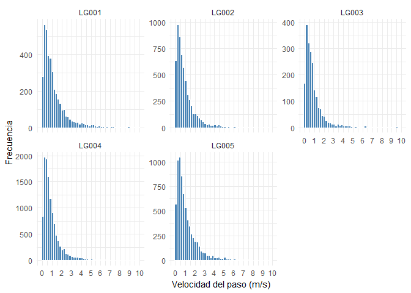

```r
gps_data_clean %>%
  ggplot(., aes(x = speed_ms)) +
  geom_histogram(bins = 50, fill = "steelblue", color = "white") +
  scale_x_continuous(breaks = seq(0, 10, by = 1)) +  # más referencias
  labs(x = "Velocidad del paso (m/s)", y = "Frecuencia") +
  facet_wrap(~ dog_id, scales = "free_y") +
  theme_minimal()
```

Luego, se grafican las distancias recorridas entre puntos consecutivos a lo largo del tiempo para cada perro.

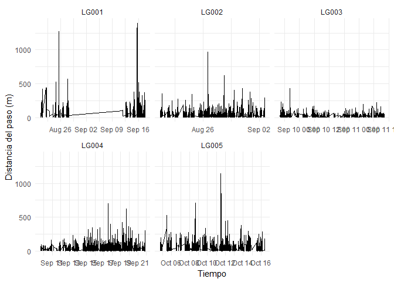

```r
gps_data_clean %>%
  ggplot(., aes(x = timestamp, y = dist_m)) +
  geom_line() +
  facet_wrap(~ dog_id, scales = "free_x") +
  labs(x = "Tiempo", y = "Distancia del paso (m)") +
  theme_minimal()
```

También se explora la relación entre el ambiente y el comportamiento de movimiento. En el siguiente gráfico se muestra cómo varía el cambio de dirección (angle_change) según el tipo de ambiente donde está.

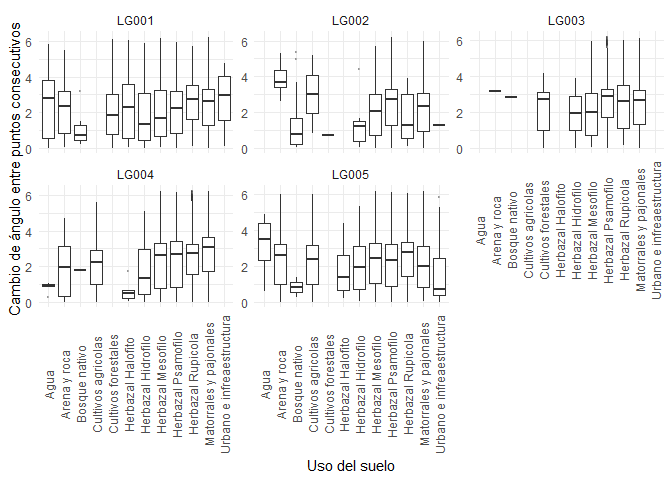

```r
gps_amb %>%
  ggplot(., aes(x = uso, y = angle_change)) +
  geom_boxplot(outlier.size = 0.5, outlier.alpha = 0.3) +
  facet_wrap(~ dog_id, scales = "free_y") +
  labs(x = "Uso del suelo", y = "Cambio de ángulo entre puntos consecutivos") +
  theme_minimal() +
  theme(axis.text.x = element_text(angle = 90, vjust = 0.5))
```

Finalmente, se compara la velocidad de movimiento en los distintos tipos de cobertura del suelo para cada perro.

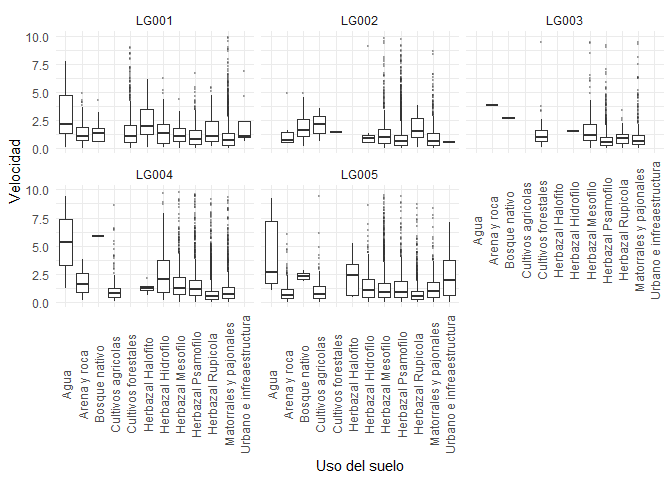

```r
ggplot(gps_amb, aes(x = uso, y = speed_ms)) +
  geom_boxplot(outlier.size = 0.5, outlier.alpha = 0.3) +
  facet_wrap(~dog_id) +
  theme_minimal() +
  theme(axis.text.x = element_text(angle = 90, vjust = 0.5)) +
  labs(x = "Uso del suelo", y = "Velocidad ")
```

# Resumen

- Coordenadas del punto anterior (`lon_prev`, `lat_prev`).
- Tiempo del punto anterior (`time_prev`).
- Distancia entre puntos consecutivos (`dist_m`).
- Diferencia de tiempo entre puntos (`time_diff_s`).
- Velocidad de desplazamiento entre puntos consecutivos (`speed_ms`).
- Dirección del movimiento (`angle`).
- Cambio de dirección entre pasos (`angle_change`).
- Tipos de cobertura del suelo (`uso`).